# Análise Fatorial

Euler Alencar

03/02/2022

```r
# Load the psych package-----
require(tidyverse)
require(psych)

# Download data--------------
link = 'https://assets.datacamp.com/production/repositories/2136/datasets/869615371e66021e97829feb7e19e38037ed0c14/GCBS_data.rds'
source('../01-funcoes/f_importar_rds.R')
gcbs <- importar_rds(link)
```

## Conduct a single-factor EFA

Let’s begin by using the psych package and conducting a single-factor explanatory factor analysis (EFA). The fa() function from pysch() package conducts an EFA on your data. When you’re using this in the real world, be sure to use a dataset that only contains item responses. Take about it, other types of data will cause errors or incorrect results.

We have gcbs dataset, these are examinees’ responses to 15 items from the Generic Conspiracist Beliefs Scale, which is designed to measure conspiracist beliefs.

An EFA provides information on each item’s relationship to a single factor hypothesized to be represented by each of the items. EFA results give you basic information about how well items relate to that hypothesized construct.

```r
EFA_model <- fa(gcbs)

# View the results
EFA_model
```

```
## Factor Analysis using method =  minres
## Call: fa(r = gcbs)
## Standardized loadings (pattern matrix) based upon correlation matrix
##      MR1   h2   u2 com
## Q1  0.70 0.49 0.51   1
## Q2  0.72 0.52 0.48   1
## Q3  0.64 0.41 0.59   1
## Q4  0.77 0.59 0.41   1
## Q5  0.67 0.45 0.55   1
## Q6  0.75 0.56 0.44   1
## Q7  0.73 0.54 0.46   1
## Q8  0.65 0.43 0.57   1
## Q9  0.70 0.48 0.52   1
## Q10 0.56 0.32 0.68   1
## Q11 0.72 0.52 0.48   1
## Q12 0.79 0.62 0.38   1
## Q13 0.68 0.46 0.54   1
## Q14 0.74 0.55 0.45   1
## Q15 0.57 0.33 0.67   1
##
##                 MR1
## SS loadings    7.27
## Proportion Var 0.48
##
## Mean item complexity =  1
## Test of the hypothesis that 1 factor is sufficient.
##
## The degrees of freedom for the null model are  105  and the objective function was  9.31 with Chi Square of  23173.8
## The degrees of freedom for the model are 90  and the objective function was  1.93
##
## The root mean square of the residuals (RMSR) is  0.08
## The df corrected root mean square of the residuals is  0.09
##
## The harmonic number of observations is  2495 with the empirical chi square  3398.99  with prob <  0
## The total number of observations was  2495  with Likelihood Chi Square =  4809.34  with prob <  0
##
## Tucker Lewis Index of factoring reliability =  0.761
## RMSEA index =  0.145  and the 90 % confidence intervals are  0.142 0.149
## BIC =  4105.36
## Fit based upon off diagonal values = 0.97
## Measures of factor score adequacy
##                                                    MR1
## Correlation of (regression) scores with factors   0.97
## Multiple R square of scores with factors          0.94
## Minimum correlation of possible factor scores     0.87
```

When you don’t specify the number of factors, the fa() function gives us only one factor by default.

```r
# View the factor loadings
EFA_model$loadings
```

```
##
## Loadings:
##     MR1
## Q1  0.703
## Q2  0.719
## Q3  0.638
## Q4  0.770
## Q5  0.672
## Q6  0.746
## Q7  0.734
## Q8  0.654
## Q9  0.695
## Q10 0.565
## Q11 0.719
## Q12 0.786
## Q13 0.679
## Q14 0.743
## Q15 0.574
##
##                  MR1
## SS loadings    7.267
## Proportion Var 0.484
```

### Create a path diagram of the items’ factor loadings

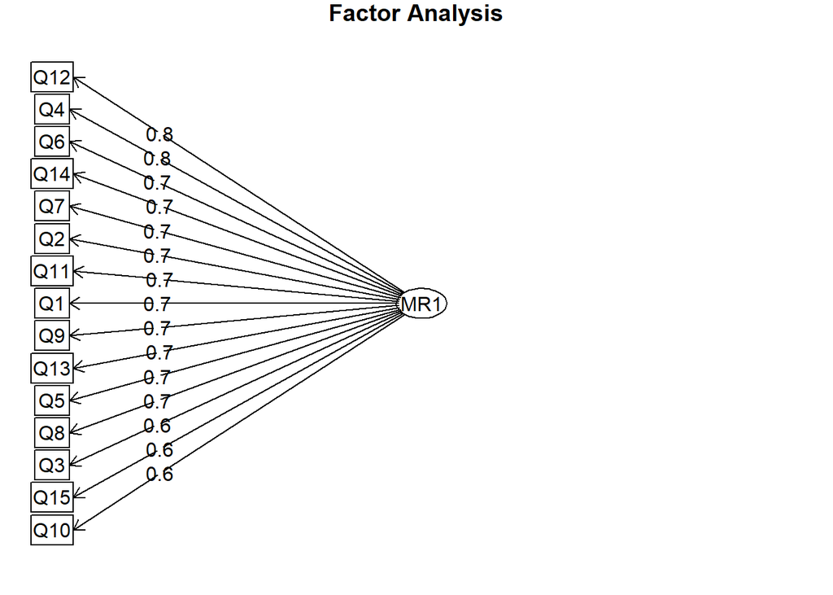

```r
fa.diagram(EFA_model)
```

```r
# Take a look at the first few lines of the response data and their corresponding sum scores
head(gcbs)
```

```
##   Q1 Q2 Q3 Q4 Q5 Q6 Q7 Q8 Q9 Q10 Q11 Q12 Q13 Q14 Q15
## 1  5  5  3  5  5  5  5  3  4   5   5   5   3   5   5
## 2  5  5  5  5  5  3  5  5  1   4   4   5   4   4   5
## 3  2  4  1  2  2  2  4  2  2   4   2   4   0   2   4
## 4  5  4  1  2  4  5  4  1  4   5   5   5   1   4   5
## 5  5  4  1  4  4  5  4  3  1   5   5   5   3   5   5
## 6  1  1  1  1  1  1  1  1  1   1   1   1   1   1   1
```

> O que é isso?

```r
rowSums(head(gcbs))
```

```
##  1  2  3  4  5  6
## 68 65 37 55 59 15
```

We look at the first few lines of individuals factors scores. This is the result of transformation of data X to a F (Factor).

```r
# Then look at the first few lines of individuals' factor scores
head(EFA_model$scores)
```

```
##             MR1
## [1,]  1.5614675
## [2,]  1.3432026
## [3,] -0.3960355
## [4,]  0.7478868
## [5,]  1.0435203
## [6,] -1.7290812
```

Distribution of scores:

```r
# To get a feel for how the factor scores are distributed, look at their summary statistics and density plot.
summary(EFA_model$scores)
```

```
##       MR1
##  Min.   :-1.854703
##  1st Qu.:-0.783260
##  Median :-0.001971
##  Mean   : 0.000000
##  3rd Qu.: 0.728568
##  Max.   : 1.949580
```

Plot a density of scores:

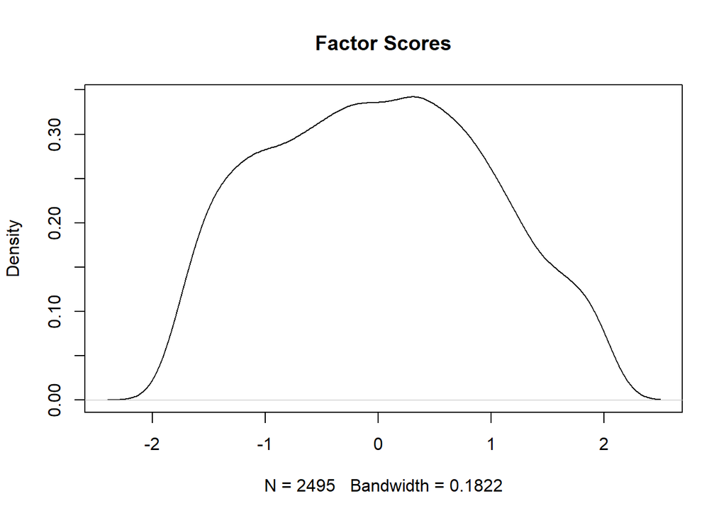

```r
plot(density(EFA_model$scores,
             na.rm = TRUE),
     main = "Factor Scores")
```

```r
# dev.off()
# par("mar")
# graphics.off()
```

### Process of delevepment

1. Develop items for your measure
2. Collect pilot data from a representative sample
3. Check out what dataset looks like
   - 3.1 – Inspect your dataset
4. Considere whether you want to use an explanatory analysis (EFA) or a confirmatory (CFA) or still both;
5. If both, split your sample into random partes, see
6. Compare the two samples to make sure they are similar

### Splitting your dataset

During the measure development process, it’s important to conduct EFA and CFA on separate datasets because using the same dataset can lead to inflated model fit statistics. Instead, you can split your dataset in half, then use one half for the EFA and the other half for the CFA.

```r
N <-  nrow(gcbs)
indices <-  seq(1, N)
indices_EFA <- sample(indices, floor(0.5*N))
indices_CFA <- indices[!(indices %in% indices_EFA)]

gcbs_EFA <- gcbs[indices_EFA,]
gcbs_CFA <- gcbs[indices_CFA,]
```

```r
# Basic descriptive statistics
describe(gcbs)
```

```
##     vars    n mean   sd median trimmed  mad min max range  skew kurtosis   se
## Q1     1 2495 3.47 1.46      4    3.59 1.48   0   5     5 -0.55    -1.10 0.03
## Q2     2 2495 2.96 1.49      3    2.96 1.48   0   5     5 -0.01    -1.40 0.03
## Q3     3 2495 2.05 1.39      1    1.82 0.00   0   5     5  0.98    -0.44 0.03
## Q4     4 2495 2.64 1.45      2    2.55 1.48   0   5     5  0.26    -1.34 0.03
## Q5     5 2495 3.25 1.47      4    3.32 1.48   0   5     5 -0.35    -1.27 0.03
## Q6     6 2495 3.11 1.51      3    3.14 1.48   0   5     5 -0.17    -1.42 0.03
## Q7     7 2495 2.67 1.51      2    2.59 1.48   0   5     5  0.28    -1.39 0.03
## Q8     8 2495 2.45 1.57      2    2.32 1.48   0   5     5  0.51    -1.30 0.03
## Q9     9 2495 2.23 1.42      2    2.05 1.48   0   5     5  0.76    -0.82 0.03
## Q10   10 2495 3.50 1.39      4    3.63 1.48   1   5     4 -0.59    -0.94 0.03
## Q11   11 2495 3.27 1.40      4    3.34 1.48   0   5     5 -0.35    -1.11 0.03
## Q12   12 2495 2.64 1.50      2    2.56 1.48   0   5     5  0.29    -1.37 0.03
## Q13   13 2495 2.10 1.38      1    1.89 0.00   0   5     5  0.89    -0.56 0.03
## Q14   14 2495 2.96 1.49      3    2.95 1.48   0   5     5 -0.02    -1.43 0.03
## Q15   15 2495 4.23 1.10      5    4.47 0.00   0   5     5 -1.56     1.71 0.02
```

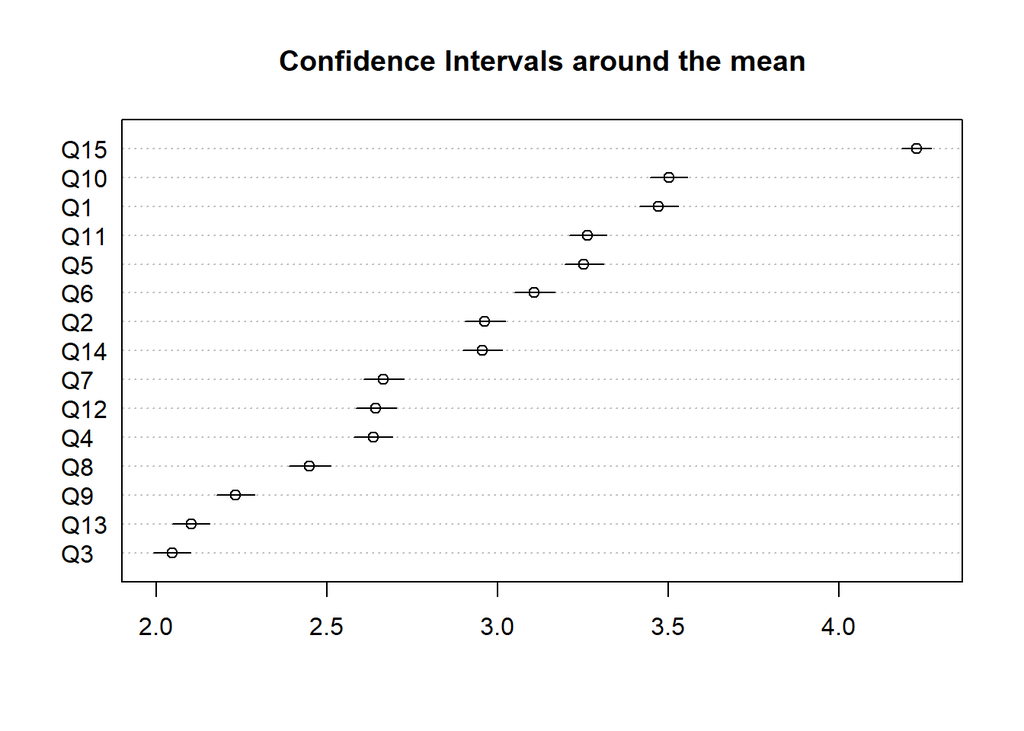

```r
# Graphical representation of error
error.dots((gcbs))
```

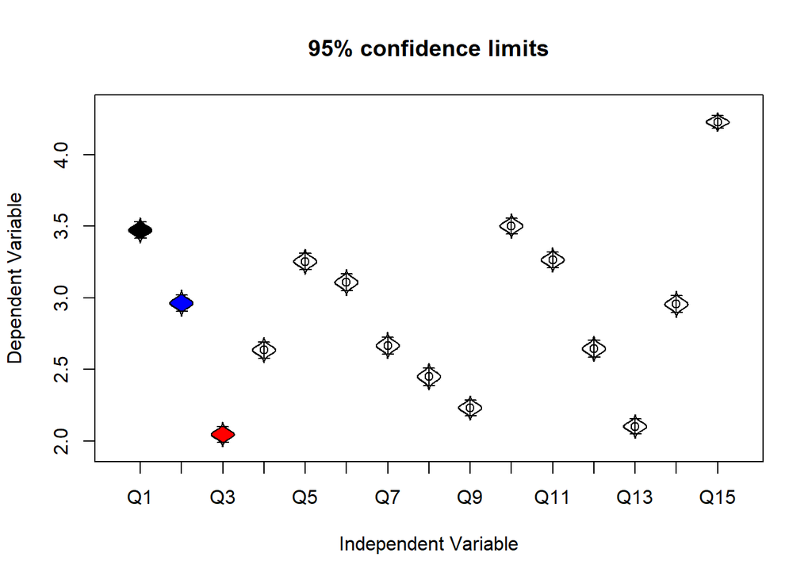

```r
# Graphical representation of error
error.bars(gcbs)
```

```r
# Establish two sets of indices to split the dataset
N <- nrow(gcbs)
indices <- seq(1, N)
indices_EFA <- sample(indices, floor((.5*N)))
indices_CFA <- indices[!(indices %in% indices_EFA)]

# Use those indices to split the dataset into halves for your EFA and CFA
gcbs_EFA <- gcbs[indices_EFA, ]
gcbs_CFA <- gcbs[indices_CFA, ]

# Precisam ter a quantidade igual de dados (diferença máxima de 1)
gcbs_EFA %>% nrow()
```

```
## [1] 1247
```

```r
gcbs_CFA %>% nrow()
```

```
## [1] 1248
```

```r
# Use the indices from the previous exercise to create a grouping variable
group_var <- vector("numeric", nrow(gcbs))
group_var[indices_EFA] <- 1
group_var[indices_CFA] <- 2

# Bind that grouping variable onto the gcbs dataset
gcbs_grouped <- cbind(gcbs, group_var)

head(gcbs_grouped)
```

```
##   Q1 Q2 Q3 Q4 Q5 Q6 Q7 Q8 Q9 Q10 Q11 Q12 Q13 Q14 Q15 group_var
## 1  5  5  3  5  5  5  5  3  4   5   5   5   3   5   5         1
## 2  5  5  5  5  5  3  5  5  1   4   4   5   4   4   5         1
## 3  2  4  1  2  2  2  4  2  2   4   2   4   0   2   4         1
## 4  5  4  1  2  4  5  4  1  4   5   5   5   1   4   5         2
## 5  5  4  1  4  4  5  4  3  1   5   5   5   3   5   5         2
## 6  1  1  1  1  1  1  1  1  1   1   1   1   1   1   1         2
```

### Compare stats across groups

A word of warning: while the group argument of describeBy() has to be a vector, the group argument of statsBy() has to be the name of a column in your dataframe. Plan accordingly!

```r
desc_by_group <- describeBy(gcbs_grouped, group = group_var)
stats_by_group <- statsBy(gcbs_grouped, group = 'group_var')

# formattable::formattable(desc_by_group$'1')
# DT::datatable(desc_by_group$'1') -> conversar com Ariane
```

### Correlation

#### Conduct a single-factor EFA

One of the easiest ways to get a feel for your dataset is to examine the relationships of your variables with each other. While base R has the cor() function, the psych package has the lowerCor() function, which only displays the lower triangle of the correlation matrix for easier viewing and interpretation.

```r
# View the lower triangle of the correlation matrix.

knitr::kable(round(lowerCor(gcbs),2))
```

```
##     Q1   Q2   Q3   Q4   Q5   Q6   Q7   Q8   Q9   Q10  Q11
## Q1  1.00
## Q2  0.53 1.00
## Q3  0.36 0.40 1.00
## Q4  0.52 0.53 0.50 1.00
## Q5  0.48 0.46 0.40 0.57 1.00
## Q6  0.63 0.55 0.40 0.61 0.50 1.00
## Q7  0.47 0.67 0.42 0.57 0.45 0.54 1.00
## Q8  0.39 0.38 0.78 0.49 0.41 0.41 0.41 1.00
## Q9  0.42 0.49 0.49 0.56 0.46 0.48 0.53 0.48 1.00
## Q10 0.44 0.38 0.32 0.40 0.43 0.41 0.39 0.36 0.37 1.00
## Q11 0.64 0.52 0.34 0.52 0.49 0.62 0.49 0.37 0.46 0.45 1.00
## Q12 0.52 0.72 0.44 0.60 0.49 0.59 0.75 0.42 0.57 0.40 0.55
## Q13 0.38 0.40 0.71 0.51 0.43 0.42 0.45 0.76 0.54 0.37 0.40
## Q14 0.53 0.50 0.43 0.60 0.54 0.55 0.52 0.45 0.55 0.41 0.56
## Q15 0.51 0.40 0.27 0.39 0.45 0.47 0.39 0.31 0.32 0.45 0.54
##     Q12  Q13  Q14  Q15
## Q12 1.00
## Q13 0.49 1.00
## Q14 0.56 0.50 1.00
## Q15 0.41 0.30 0.46 1.00
```

|  | Q1 | Q2 | Q3 | Q4 | Q5 | Q6 | Q7 | Q8 | Q9 | Q10 | Q11 | Q12 | Q13 | Q14 | Q15 |
| --- | --- | --- | --- | --- | --- | --- | --- | --- | --- | --- | --- | --- | --- | --- | --- |
| Q1 | 1.00 | 0.53 | 0.36 | 0.52 | 0.48 | 0.63 | 0.47 | 0.39 | 0.42 | 0.44 | 0.64 | 0.52 | 0.38 | 0.53 | 0.51 |
| Q2 | 0.53 | 1.00 | 0.40 | 0.53 | 0.46 | 0.55 | 0.67 | 0.38 | 0.49 | 0.38 | 0.52 | 0.72 | 0.40 | 0.50 | 0.40 |
| Q3 | 0.36 | 0.40 | 1.00 | 0.50 | 0.40 | 0.40 | 0.42 | 0.78 | 0.49 | 0.32 | 0.34 | 0.44 | 0.71 | 0.43 | 0.27 |
| Q4 | 0.52 | 0.53 | 0.50 | 1.00 | 0.57 | 0.61 | 0.57 | 0.49 | 0.56 | 0.40 | 0.52 | 0.60 | 0.51 | 0.60 | 0.39 |
| Q5 | 0.48 | 0.46 | 0.40 | 0.57 | 1.00 | 0.50 | 0.45 | 0.41 | 0.46 | 0.43 | 0.49 | 0.49 | 0.43 | 0.54 | 0.45 |
| Q6 | 0.63 | 0.55 | 0.40 | 0.61 | 0.50 | 1.00 | 0.54 | 0.41 | 0.48 | 0.41 | 0.62 | 0.59 | 0.42 | 0.55 | 0.47 |
| Q7 | 0.47 | 0.67 | 0.42 | 0.57 | 0.45 | 0.54 | 1.00 | 0.41 | 0.53 | 0.39 | 0.49 | 0.75 | 0.45 | 0.52 | 0.39 |
| Q8 | 0.39 | 0.38 | 0.78 | 0.49 | 0.41 | 0.41 | 0.41 | 1.00 | 0.48 | 0.36 | 0.37 | 0.42 | 0.76 | 0.45 | 0.31 |
| Q9 | 0.42 | 0.49 | 0.49 | 0.56 | 0.46 | 0.48 | 0.53 | 0.48 | 1.00 | 0.37 | 0.46 | 0.57 | 0.54 | 0.55 | 0.32 |
| Q10 | 0.44 | 0.38 | 0.32 | 0.40 | 0.43 | 0.41 | 0.39 | 0.36 | 0.37 | 1.00 | 0.45 | 0.40 | 0.37 | 0.41 | 0.45 |
| Q11 | 0.64 | 0.52 | 0.34 | 0.52 | 0.49 | 0.62 | 0.49 | 0.37 | 0.46 | 0.45 | 1.00 | 0.55 | 0.40 | 0.56 | 0.54 |
| Q12 | 0.52 | 0.72 | 0.44 | 0.60 | 0.49 | 0.59 | 0.75 | 0.42 | 0.57 | 0.40 | 0.55 | 1.00 | 0.49 | 0.56 | 0.41 |
| Q13 | 0.38 | 0.40 | 0.71 | 0.51 | 0.43 | 0.42 | 0.45 | 0.76 | 0.54 | 0.37 | 0.40 | 0.49 | 1.00 | 0.50 | 0.30 |
| Q14 | 0.53 | 0.50 | 0.43 | 0.60 | 0.54 | 0.55 | 0.52 | 0.45 | 0.55 | 0.41 | 0.56 | 0.56 | 0.50 | 1.00 | 0.46 |
| Q15 | 0.51 | 0.40 | 0.27 | 0.39 | 0.45 | 0.47 | 0.39 | 0.31 | 0.32 | 0.45 | 0.54 | 0.41 | 0.30 | 0.46 | 1.00 |

```r
#formattable::formattable()
```

Vamos usar cores para criar uma matriz semelhante.

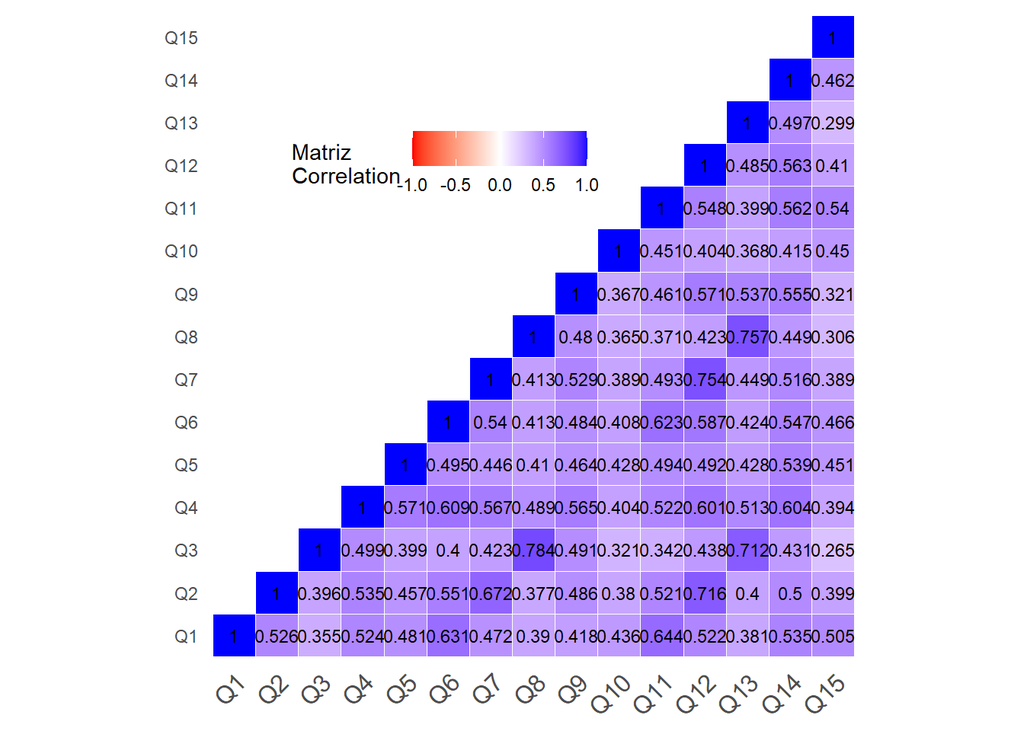

```r
# Find the correlation
rho_gcbs <- cor(gcbs)

# Incluir NA na parte de baixo do correlação

# Get lower triangle of the correlation matrix
get_lower_tri<-function(cormat){
  cormat[upper.tri(cormat)] <- NA
  return(cormat)
}
# Get upper triangle of the correlation matrix
get_upper_tri <- function(cormat){
  cormat[lower.tri(cormat)]<- NA
  return(cormat)
}

rho_gcbs_upper <- get_upper_tri(rho_gcbs)

# Melt the correlation matrix
melted_rho <- reshape2::melt(rho_gcbs_upper, na.rm = TRUE)

# Alterações no tema
alterar_resto_thema <-
  theme(
    axis.title.x = element_blank(),
    axis.title.y = element_blank(),
    panel.grid.major = element_blank(),
    panel.border = element_blank(),
    panel.background = element_blank(),
    axis.ticks = element_blank(),
    legend.justification = c(1, 0),
    legend.position = c(0.6, 0.7),
    legend.direction = "horizontal")

# Heatmap
ggplot(data = melted_rho, aes(Var2, Var1, fill = value))+
  geom_tile(color = "white")+
  scale_fill_gradient2(low = "red", high = "blue", mid = "white",
                       midpoint = 0, limit = c(-1,1), space = "Lab",
                       name="Matriz\nCorrelation") +
  theme_minimal()+
  theme(axis.text.x = element_text(angle = 45, vjust = 1,
                                   size = 12, hjust = 1))+
  coord_fixed() +
  geom_text(aes(Var2, Var1, label = round(x = value, digits = 3)), color = "black", size = 3) +
  alterar_resto_thema
```

Podemos também ver a matriz de correlação completa.

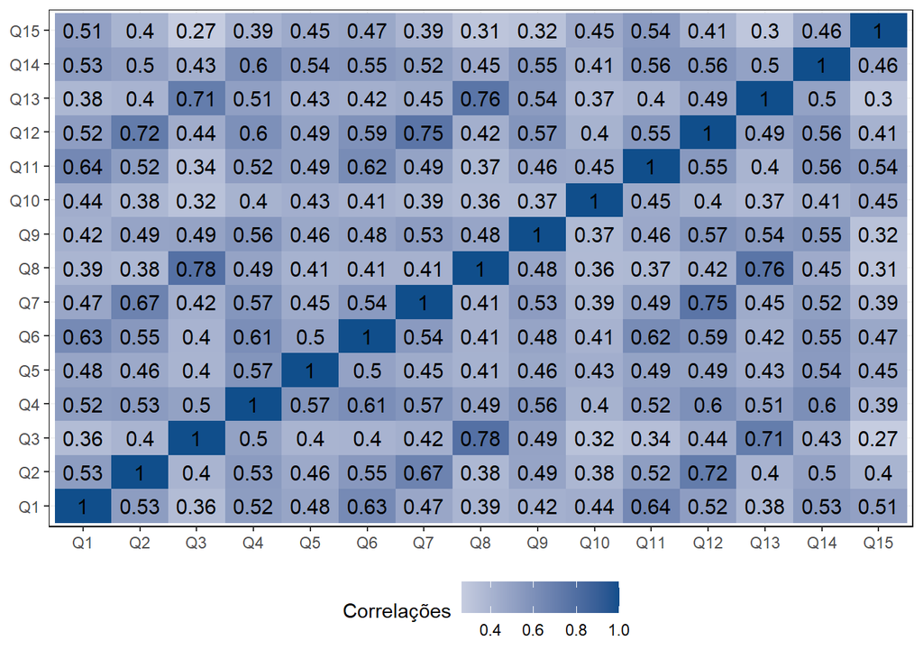

```r
# Salvando a Matriz de Correlações
rho_gcbs <- cor(gcbs)
####################################################################
# Construindo um mapa de calor a partir das correlações
rho_gcbs %>%
  reshape2::melt() %>%
  ggplot() +
  geom_tile(aes(x = Var1, y = Var2, fill = value)) +
  geom_text(aes(x = Var1, y = Var2, label = round(x = value, digits = 2)),
            size = 4) +
  labs(x = NULL,
       y = NULL,
       fill = "Correlações") +
  scale_fill_gradient2(low = "brown4",
                       mid = "white",
                       high = "dodgerblue4",
                       midpoint = 0) +
  theme(panel.background = element_rect("white"),
        panel.grid = element_line("grey95"),
        panel.border = element_rect(NA),
        legend.position = "bottom",
        axis.text.x = element_text(angle = 0))
```

#### Test for corr - p-values

```r
# Check out the p-values created when calculating correlations. Significant values mean items are meaningfully correlated.
corr.test(gcbs, use = 'pairwise.complete.obs')$p
```

```
##                Q1            Q2            Q3            Q4            Q5
## Q1   0.000000e+00 1.038105e-175  2.525793e-74 1.746323e-174 5.801103e-143
## Q2  1.384140e-177  0.000000e+00  6.236650e-93 8.388030e-183 1.237758e-127
## Q3   3.608276e-75  3.282447e-94  0.000000e+00 1.087371e-155  1.282718e-94
## Q4  2.359896e-176 1.075388e-184 1.647531e-157  0.000000e+00 7.309882e-214
## Q5  1.054746e-144 2.578663e-129  6.108182e-96 8.032837e-216  0.000000e+00
## Q6  1.477903e-277 1.757495e-198  1.248831e-96 3.037754e-253 1.470071e-154
## Q7  8.142449e-139  0.000000e+00 5.318107e-109 5.260693e-212 2.336455e-122
## Q8   1.549786e-91  5.579984e-85  0.000000e+00 1.898345e-150 1.224898e-101
## Q9  4.344797e-106 3.376084e-148 3.104324e-151 3.108940e-210 1.462606e-133
## Q10 3.550942e-116  9.131376e-87  6.760094e-61  1.298818e-98 1.476449e-111
## Q11 9.499179e-292 1.822105e-173  2.580298e-69 9.037626e-175 2.540009e-153
## Q12 9.097129e-175  0.000000e+00 1.005698e-117 1.550592e-244 2.612164e-152
## Q13  9.052542e-87  1.297778e-96  0.000000e+00 1.798859e-167 1.168044e-111
## Q14 1.912163e-184 3.969981e-158 1.103607e-113 8.219433e-248 4.008639e-188
## Q15 9.793389e-162  3.129498e-96  1.676489e-41  1.255385e-93 3.849304e-125
##                Q6            Q7            Q8            Q9           Q10
## Q1  1.448345e-275 4.315498e-137  2.634636e-90 1.433783e-104 1.420377e-114
## Q2  1.493871e-196  0.000000e+00  6.695981e-84 1.958129e-146  1.267356e-85
## Q3   2.997195e-95 1.861338e-107  0.000000e+00 1.862595e-149  2.704037e-60
## Q4  2.916244e-251 4.734624e-210 1.120024e-148 2.766957e-208  3.376926e-97
## Q5  9.408454e-153 9.813111e-121 3.429715e-100 7.459290e-132 5.462862e-110
## Q6   0.000000e+00 2.582592e-187 1.111480e-101 4.903141e-145  2.966233e-99
## Q7  3.149502e-189  0.000000e+00 1.110564e-101 4.177923e-178  1.437786e-89
## Q8  3.704932e-103 3.582463e-103  0.000000e+00 3.981155e-142  1.778530e-78
## Q9  8.755609e-147 5.497267e-180 7.372509e-144  0.000000e+00  2.784487e-79
## Q10 1.098605e-100  9.585238e-91  2.223163e-79  3.093874e-80  0.000000e+00
## Q11 4.981130e-268 8.601767e-153  2.643708e-82 1.655959e-131 4.633595e-125
## Q12 2.403960e-231  0.000000e+00 5.764588e-109 7.071640e-216  1.561964e-98
## Q13 1.353745e-109 7.858024e-124  0.000000e+00 2.581509e-186  4.747674e-81
## Q14 7.044729e-195 6.545724e-170 2.485870e-124 2.858794e-201 3.168647e-104
## Q15 1.340087e-134  7.843219e-91  4.328489e-55  4.516727e-61 2.157366e-124
##               Q11           Q12           Q13           Q14           Q15
## Q1  9.404187e-290 6.597467e-173  1.267356e-85 1.472366e-182 6.659505e-160
## Q2  1.293694e-171  0.000000e+00  2.997195e-95 2.659887e-156  6.884895e-95
## Q3   1.548179e-68 4.123361e-116  0.000000e+00 4.304066e-112  1.676489e-41
## Q4  6.597467e-173 1.457557e-242 1.241212e-165 7.808462e-246  2.259693e-92
## Q5  1.600206e-151 1.593420e-150 4.438568e-110 3.206912e-186 1.809173e-123
## Q6  4.831696e-266 2.235683e-229 4.873482e-108 5.847125e-193 6.968453e-133
## Q7  5.333096e-151  0.000000e+00 3.378951e-122 4.582007e-168  1.254915e-89
## Q8   2.908079e-81 1.959960e-107  0.000000e+00 1.093783e-122  1.298547e-54
## Q9  8.114201e-130 6.505909e-214 2.039392e-184 2.458563e-199  2.258363e-60
## Q10 2.131454e-123  3.904910e-97  4.747674e-80 1.013967e-102 9.708145e-123
## Q11  0.000000e+00 1.571210e-193  1.584049e-94 1.610933e-205 1.319712e-186
## Q12 1.870488e-195  0.000000e+00 9.395071e-146 1.350081e-206 3.398356e-100
## Q13  7.920246e-96 1.648258e-147  0.000000e+00 6.585550e-154  2.751475e-52
## Q14 1.851647e-207 1.534183e-208 1.013162e-155  0.000000e+00 2.883420e-130
## Q15 1.629274e-188 1.171847e-101  1.375737e-52 5.766839e-132  0.000000e+00
```

Data set has more than 2000 observations. The statistical significance is affected by sample size.

#### Test for corr - confidente interval

```r
# View the confidence intervals created when calculating correlations.
corr.test(gcbs, use = 'pairwise.complete.obs')$ci
```

```
##             lower         r     upper             p
## Q1-Q2   0.4970162 0.5259992 0.5538098 1.384140e-177
## Q1-Q3   0.3206223 0.3553928 0.3892067  3.608276e-75
## Q1-Q4   0.4953852 0.5244323 0.5523079 2.359896e-176
## Q1-Q5   0.4503342 0.4810747 0.5106759 1.054746e-144
## Q1-Q6   0.6071117 0.6313131 0.6543444 1.477903e-277
## Q1-Q7   0.4412058 0.4722710 0.5022057 8.142449e-139
## Q1-Q8   0.3564216 0.3902059 0.4229712  1.549786e-91
## Q1-Q9   0.3850453 0.4179718 0.4498355 4.344797e-106
## Q1-Q10  0.4034438 0.4357865 0.4670415 3.550942e-116
## Q1-Q11  0.6199265 0.6435136 0.6659388 9.499179e-292
## Q1-Q12  0.4932727 0.5224025 0.5503620 9.097129e-175
## Q1-Q13  0.3464313 0.3805006 0.4135673  9.052542e-87
## Q1-Q14  0.5059498 0.5345780 0.5620298 1.912163e-184
## Q1-Q15  0.4753633 0.5051815 0.5338405 9.793389e-162
## Q2-Q3   0.3618855 0.3955108 0.4281083  3.282447e-94
## Q2-Q4   0.5062706 0.5348860 0.5623248 1.075388e-184
## Q2-Q5   0.4259018 0.4574975 0.4879788 2.578663e-129
## Q2-Q6   0.5234810 0.5513960 0.5781285 1.757495e-198
## Q2-Q7   0.6501266 0.6722188 0.6931753  0.000000e+00
## Q2-Q8   0.3425926 0.3767693 0.4099501  5.579984e-85
## Q2-Q9   0.4556319 0.4861810 0.5155863 3.376084e-148
## Q2-Q10  0.3464233 0.3804928 0.4135598  9.131376e-87
## Q2-Q11  0.4915283 0.5207263 0.5487548 1.822105e-173
## Q2-Q12  0.6962013 0.7158851 0.7344931  0.000000e+00
## Q2-Q13  0.3667134 0.4001964 0.4326439  1.297778e-96
## Q2-Q14  0.4702225 0.5002339 0.5290898 3.969981e-158
## Q2-Q15  0.3659505 0.3994560 0.4319274  3.129498e-96
## Q3-Q4   0.4693335 0.4993781 0.5282679 1.647531e-157
## Q3-Q5   0.3653695 0.3988923 0.4313817  6.108182e-96
## Q3-Q6   0.3667467 0.4002287 0.4326752  1.248831e-96
## Q3-Q7   0.3904688 0.4232258 0.4549125 5.318107e-109
## Q3-Q8   0.7683496 0.7839542 0.7986273  0.000000e+00
## Q3-Q9   0.4601647 0.4905484 0.5197845 3.104324e-151
## Q3-Q10  0.2853436 0.3209913 0.3557521  6.760094e-61
## Q3-Q11  0.3066780 0.3418064 0.3760050  2.580298e-69
## Q3-Q12  0.4061739 0.4384278 0.4695906 1.005698e-117
## Q3-Q13  0.6919756 0.7118867 0.7307155  0.000000e+00
## Q3-Q14  0.3989973 0.4314834 0.4628876 1.103607e-113
## Q3-Q15  0.2285790 0.2654400 0.3015410  1.676489e-41
```

[output cut: 51 more lines]

```
## Q10-Q11 0.4188025 0.4506384 0.4813679 4.633595e-125
## Q10-Q12 0.3705162 0.4038857 0.4362140  1.561964e-98
## Q10-Q13 0.3339871 0.3684007 0.4018335  4.747674e-81
## Q10-Q14 0.3815258 0.4145611 0.4465387 3.168647e-104
## Q10-Q15 0.4176732 0.4495470 0.4803157 2.157366e-124
## Q11-Q12 0.5197817 0.5478491 0.5747350 1.870488e-195
## Q11-Q13 0.3651436 0.3986730 0.4311694  7.920246e-96
## Q11-Q14 0.5342028 0.5616704 0.5879532 1.851647e-207
## Q11-Q15 0.5111332 0.5395529 0.5667941 1.629274e-188
## Q12-Q13 0.4545949 0.4851817 0.5146255 1.648258e-147
## Q12-Q14 0.5354702 0.5628844 0.5891136 1.534183e-208
## Q12-Q15 0.3766079 0.4097936 0.4419289 1.171847e-101
## Q13-Q14 0.4667464 0.4968874 0.5258754 1.013162e-155
## Q13-Q15 0.2625236 0.2986885 0.3340155  1.375737e-52
## Q14-Q15 0.4302457 0.4616926 0.4920203 5.766839e-132
```

### Internal reliability

You know how to examine how individual items perform in your measure, but what about how well those items relate to each other - the overall internal reliability of a measure? Coefficient alpha (also called Cronbach’s alpha) and split-half reliability are two common ways of assessing reliability. These statistics are a function of the measure length and items’ interrelatedness, which you just investigated by looking at the correlation matrix.

In reliability values greater than 0.8 are desired, though some fields of study have higher or lower guidelines.

Resumo: * Alpha de Cronback - Verifica a consistência da sua medida. Alpha deve estar acima de 0.8 * O que seria medida? um item ou todos eles juntos?

```r
alpha(x = gcbs)
```

```
##
## Reliability analysis
## Call: alpha(x = gcbs)
##
##   raw_alpha std.alpha G6(smc) average_r S/N   ase mean sd median_r
##       0.93      0.93    0.94      0.48  14 0.002  2.9  1     0.47
##
##  lower alpha upper     95% confidence boundaries
## 0.93 0.93 0.94
##
##  Reliability if an item is dropped:
##     raw_alpha std.alpha G6(smc) average_r S/N alpha se  var.r med.r
## Q1       0.93      0.93    0.94      0.48  13   0.0021 0.0105  0.46
## Q2       0.93      0.93    0.94      0.48  13   0.0021 0.0099  0.47
## Q3       0.93      0.93    0.94      0.49  13   0.0020 0.0084  0.48
## Q4       0.93      0.93    0.94      0.47  13   0.0022 0.0105  0.46
## Q5       0.93      0.93    0.94      0.48  13   0.0021 0.0112  0.48
## Q6       0.93      0.93    0.94      0.48  13   0.0021 0.0104  0.46
## Q7       0.93      0.93    0.94      0.48  13   0.0021 0.0098  0.47
## Q8       0.93      0.93    0.94      0.48  13   0.0020 0.0086  0.49
## Q9       0.93      0.93    0.94      0.48  13   0.0021 0.0108  0.46
## Q10      0.93      0.93    0.94      0.49  14   0.0020 0.0102  0.49
## Q11      0.93      0.93    0.94      0.48  13   0.0021 0.0104  0.46
## Q12      0.93      0.93    0.94      0.47  13   0.0022 0.0093  0.46
## Q13      0.93      0.93    0.94      0.48  13   0.0021 0.0092  0.48
## Q14      0.93      0.93    0.94      0.48  13   0.0021 0.0109  0.46
## Q15      0.93      0.93    0.94      0.49  14   0.0020 0.0095  0.49
##
##  Item statistics
##        n raw.r std.r r.cor r.drop mean  sd
## Q1  2495  0.73  0.73  0.70   0.68  3.5 1.5
## Q2  2495  0.74  0.74  0.72   0.69  3.0 1.5
## Q3  2495  0.68  0.67  0.66   0.62  2.0 1.4
## Q4  2495  0.78  0.78  0.76   0.74  2.6 1.5
## Q5  2495  0.70  0.70  0.67   0.65  3.3 1.5
## Q6  2495  0.76  0.76  0.74   0.72  3.1 1.5
## Q7  2495  0.75  0.75  0.73   0.70  2.7 1.5
## Q8  2495  0.69  0.69  0.68   0.63  2.5 1.6
## Q9  2495  0.72  0.72  0.69   0.67  2.2 1.4
## Q10 2495  0.61  0.61  0.57   0.55  3.5 1.4
```

[output cut: 8 more lines]

```
## Q1  0.00 0.16 0.12 0.12 0.27 0.32    0
## Q2  0.01 0.23 0.19 0.16 0.20 0.22    0
## Q3  0.00 0.55 0.13 0.12 0.10 0.10    0
## Q4  0.00 0.32 0.18 0.15 0.20 0.14    0
## Q5  0.00 0.19 0.14 0.13 0.28 0.26    0
## Q6  0.00 0.23 0.15 0.15 0.23 0.24    0
## Q7  0.00 0.33 0.19 0.13 0.18 0.17    0
## Q8  0.00 0.44 0.12 0.14 0.12 0.18    0
## Q9  0.00 0.45 0.19 0.12 0.12 0.11    0
## Q10 0.00 0.14 0.12 0.14 0.30 0.30    0
## Q11 0.00 0.16 0.14 0.19 0.27 0.24    0
## Q12 0.00 0.34 0.18 0.15 0.17 0.17    0
## Q13 0.01 0.51 0.15 0.15 0.10 0.09    0
## Q14 0.00 0.25 0.17 0.15 0.22 0.20    0
## Q15 0.00 0.05 0.05 0.08 0.27 0.55    0
```

```r
splitHalf(gcbs)
```

```
## Split half reliabilities
## Call: splitHalf(r = gcbs)
##
## Maximum split half reliability (lambda 4) =  0.95
## Guttman lambda 6                          =  0.94
## Average split half reliability            =  0.93
## Guttman lambda 3 (alpha)                  =  0.93
## Guttman lambda 2                          =  0.93
## Minimum split half reliability  (beta)    =  0.86
## Average interitem r =  0.48  with median =  0.47
```

## Conduct a multidimensional-factor EFA

We you use the strategy method of split data in previously section.

```r
# Establish two sets of indices to split the dataset
N <-  nrow(bfi)
indices <-  seq(1, N)
indices_EFA <- sample(indices, floor(0.5*N))
indices_CFA <- indices[!(indices %in% indices_EFA)]

# Use those indices to split the dataset into halves for your EFA and CFA
bfi_EFA <- bfi[indices_EFA, ]
bfi_CFA <- bfi[indices_CFA, ]
```

### Calculating eigenvalues

To empirically determine the dimensionality of your data, a common strategy is to examine the eigenvalues. Eigenvalues are numeric representations of the amount of variance explained by each factor or component. Eigenvalues are calculated from a correlation matrix, so you’ll need to use cor() to calculate and store the dataset’s correlation matrix before calculating eigenvalues. You’ll need to specify that you want to use pairwise complete observations. The default is to use everything, but if your dataset has any missing values, this will leave you with a matrix full of NAs.

You’ll do these calculations on the bfi_EFA dataset you just created - remember, you’re saving the data in bfi_CFA for your confirmatory analysis!

```r
# Calculate the correlation matrix first
bfi_EFA_cor <- cor(bfi_EFA, use = 'pairwise.complete.obs')

# Then use that correlation matrix to calculate eigenvalues
eigenvals <- eigen(bfi_EFA_cor)

# Look at the eigenvalues returned
eigenvals$values
```

```
##  [1] 5.0587892 2.8123922 2.1079534 1.9785864 1.6626454 1.2780725 1.1485714
##  [8] 0.9333021 0.8404329 0.8199798 0.7656063 0.7067923 0.6998570 0.6620041
## [15] 0.6410176 0.5850941 0.5523054 0.5303892 0.5151412 0.5021733 0.4825275
## [22] 0.4538962 0.4212270 0.4118281 0.3979714 0.3860756 0.3746859 0.2706826
```